# Evaluacion 1

Jorge Cáceres Barrales

2024-06-18

# Objetivo de Investigación

Analizar los datos de permisos de circulación vehicular en Calbuco para identificar patrones y tendencias, y proponer mejoras en la gestión de permisos.

# Introducción

## Descripción del Conjunto de Datos

El conjunto de datos seleccionado para este análisis proviene de los registros de permisos de circulación en la Municipalidad de Calbuco. Este conjunto de datos contiene información detallada sobre vehículos y sus permisos de circulación, incluyendo variables como el tipo de vehículo, año de fabricación, marca, modelo, color, tipo de combustible, y valor del permiso, entre otros.

## Objetivos del Análisis

El objetivo principal de este análisis es investigar y comprender los patrones y tendencias en los permisos de circulación vehicular en Calbuco. Específicamente, se busca:

```
1.  Identificar las características más comunes de los vehículos que obtienen permisos de circulación.
2.  Analizar la distribución temporal de la obtención de permisos.
3.  Explorar posibles relaciones entre las características de los vehículos y el costo del permiso.
4.  Realizar un modelo que permita estimar la cantidad de pagos que se recibiran en un periodo de tiempo.
```

# Procesamiento de Datos

El preprocesamiento de datos es un paso crucial para garantizar que los datos estén limpios y listos para el análisis. A continuación, se detallan los pasos tomados para limpiar y preparar los datos

## Carga Librerias

```r
# Cargar librerías necesarias
library(dplyr)
library(stringr)
library(caret)
```

```r
library(corrplot)
library(e1071)
library(xgboost)
library(ROSE)
library(pROC)
library(factoextra)
library(kableExtra)
library(summarytools)
library(httr)
library(zoo)
```

## Cargas funciones y base de datos

```r
# Enlace raw al archivo de funciones en GitHub
source("https://raw.githubusercontent.com/jkcrs1/R/main/funciones.R")
# Permisos circulación  pagados en la municipalidad de calbuco
url3 <- "https://github.com/jkcrs1/R/raw/main/permiso_circulacion_calbuco.csv"

# Prueba con diferentes codificaciones
permiso <- read.csv(url3, sep = ";", fileEncoding = "ISO-8859-1")
```

## Tipos de Variables

Utilizando el paquete summarytools, se genera un resumen detallado de todas las variables del dataframe. Este informe incluye estadísticas descriptivas, frecuencias, gráficos de barras para variables categóricas y otras visualizaciones útiles para el análisis de datos.

```r
# Configurar el entorno de summarytools para HTML
st_options(style = "rmarkdown", plain.ascii = FALSE)

# Obtener un resumen de los datos utilizando summarytools y renderizar en HTML
dfSummary(permiso) %>%
  print(method = 'render')
```

Data Frame Summary

permiso

**Dimensions**: 63886 x 24  
**Duplicates**: 0

| **No** | **Variable** | **Stats / Values** | **Freqs (% of Valid)** | **Graph** | **Valid** | **Missing** |
| --- | --- | --- | --- | --- | --- | --- |
| 1 | Municipalidad [character] | 1. Calbuco | 63886 ( 100.0% ) |  | 63886 (100.0%) | 0 (0.0%) |
| 2 | Grupo.Vehiculo [character] | 1. Carga 2. Transporte Publico 3. Vehiculo Liviano | 2901 ( 4.5% ) 3124 ( 4.9% ) 57861 ( 90.6% ) |  | 63886 (100.0%) | 0 (0.0%) |
| 3 | Placa [character] | 1. BPJC-93 2. DSJC-63 3. BGRR-94 4. CDWD-10 5. DSHK-87 6. FDFC-14 7. GCLT-91 8. GCVD-49 9. PC-2600 10. ZT-6085 [ 17858 others ] | 18 ( 0.0% ) 18 ( 0.0% ) 17 ( 0.0% ) 17 ( 0.0% ) 17 ( 0.0% ) 17 ( 0.0% ) 17 ( 0.0% ) 17 ( 0.0% ) 17 ( 0.0% ) 17 ( 0.0% ) 63714 ( 99.7% ) |  | 63886 (100.0%) | 0 (0.0%) |
| 4 | Digito [character] | 1. 0 2. 5 3. 3 4. 7 5. 9 6. 1 7. 2 8. K 9. 4 10. 6 [ 3 others ] | 6218 ( 9.7% ) 5914 ( 9.3% ) 5903 ( 9.2% ) 5820 ( 9.1% ) 5812 ( 9.1% ) 5809 ( 9.1% ) 5779 ( 9.0% ) 5707 ( 8.9% ) 5703 ( 8.9% ) 5603 ( 8.8% ) 5618 ( 8.8% ) |  | 63886 (100.0%) | 0 (0.0%) |
| 5 | Codigo.SII [character] | 1. NULL 2. SD050028314 3. SD050028214 4. CT176023711 5. SD050029415 6. HB050011513 7. SD050028313 8. CT235013714 9. CT235013313 10. CT235013314 [ 7950 others ] | 6801 ( 10.6% ) 208 ( 0.3% ) 194 ( 0.3% ) 150 ( 0.2% ) 131 ( 0.2% ) 126 ( 0.2% ) 112 ( 0.2% ) 111 ( 0.2% ) 109 ( 0.2% ) 108 ( 0.2% ) 55836 ( 87.4% ) |  | 63886 (100.0%) | 0 (0.0%) |
| 6 | Ano.Vehiculo [integer] | Mean (sd) : 2009.3 (7.6) min ≤ med ≤ max: 1966 ≤ 2011 ≤ 2024 IQR (CV) : 10 (0) | 55 distinct values |  | 63886 (100.0%) | 0 (0.0%) |
| 7 | Tasacion [character] | 1. 1 2. 1,5 3. 0 4. 3 5. 0,5 6. 2 7. 1390000 8. 3350000 9. 1330000 10. 1080000 [ 10830 others ] | 3628 ( 5.7% ) 933 ( 1.5% ) 686 ( 1.1% ) 611 ( 1.0% ) 517 ( 0.8% ) 422 ( 0.7% ) 158 ( 0.2% ) 129 ( 0.2% ) 127 ( 0.2% ) 125 ( 0.2% ) 56550 ( 88.5% ) |  | 63886 (100.0%) | 0 (0.0%) |
| 8 | Tipo.de.Pago [character] | 1. Internet 2. Presencial | 11657 ( 18.2% ) 52229 ( 81.8% ) |  | 63886 (100.0%) | 0 (0.0%) |
| 9 | Valor_Neto [character] | 1. 32333 2. 23510 3. 23.115 4. 24.837 5. 24,837 6. 30885 7. 22478 8. 21599 9. 20.468 10. 30884 [ 26779 others ] | 1334 ( 2.1% ) 1063 ( 1.7% ) 992 ( 1.6% ) 970 ( 1.5% ) 969 ( 1.5% ) 914 ( 1.4% ) 897 ( 1.4% ) 807 ( 1.3% ) 684 ( 1.1% ) 551 ( 0.9% ) 54705 ( 85.6% ) |  | 63886 (100.0%) | 0 (0.0%) |
| 10 | Valor_IPC [character] | 1. 0 2. 194 3. 46 4. 67 5. 86 6. 174 7. 47 8. 102 9. 309 10. 402 [ 2909 others ] | 50977 ( 79.8% ) 260 ( 0.4% ) 231 ( 0.4% ) 212 ( 0.3% ) 191 ( 0.3% ) 173 ( 0.3% ) 167 ( 0.3% ) 163 ( 0.3% ) 117 ( 0.2% ) 97 ( 0.2% ) 11298 ( 17.7% ) |  | 63886 (100.0%) | 0 (0.0%) |
| 11 | Valor_Multa [character] | 1. 0 2. 463 3. 373 4. 488 5. 347 6. 338 7. 353 8. 745 9. 325 10. 309 [ 5982 others ] | 47242 ( 73.9% ) 358 ( 0.6% ) 277 ( 0.4% ) 252 ( 0.4% ) 211 ( 0.3% ) 204 ( 0.3% ) 195 ( 0.3% ) 189 ( 0.3% ) 182 ( 0.3% ) 152 ( 0.2% ) 14624 ( 22.9% ) |  | 63886 (100.0%) | 0 (0.0%) |
| 12 | Valor.Pagado [character] | 1. 32333 2. 23510 3. 23.115 4. 24.837 5. 24,837 6. 30885 7. 22478 8. 21599 9. 20.468 10. 30884 [ 26852 others ] | 1334 ( 2.1% ) 1063 ( 1.7% ) 992 ( 1.6% ) 970 ( 1.5% ) 969 ( 1.5% ) 914 ( 1.4% ) 897 ( 1.4% ) 807 ( 1.3% ) 684 ( 1.1% ) 551 ( 0.9% ) 54705 ( 85.6% ) |  | 63886 (100.0%) | 0 (0.0%) |
| 13 | Forma.Pago [character] | 1. 1ra. Cuota 2. 2da. Cuota 3. Total | 13093 ( 20.5% ) 11094 ( 17.4% ) 39699 ( 62.1% ) |  | 63886 (100.0%) | 0 (0.0%) |
| 14 | Fecha_Pago [character] | 1. 27-04-24 2. 29-03-18 3. 31-03-17 4. 31-03-16 5. 2020-04-30T00:00:00 6. 30-04-20 7. 31-03-23 8. 31-03-14 9. 28-03-18 10. 31-03-15 [ 1901 others ] | 724 ( 1.1% ) 482 ( 0.8% ) 466 ( 0.7% ) 426 ( 0.7% ) 398 ( 0.6% ) 398 ( 0.6% ) 395 ( 0.6% ) 382 ( 0.6% ) 380 ( 0.6% ) 373 ( 0.6% ) 59462 ( 93.1% ) |  | 63886 (100.0%) | 0 (0.0%) |
| 15 | Ano.Permiso [integer] | Mean (sd) : 2018.9 (3.2) min ≤ med ≤ max: 2007 ≤ 2019 ≤ 2024 IQR (CV) : 6 (0) | 18 distinct values |  | 63886 (100.0%) | 0 (0.0%) |
| 16 | Tipo.Vehiculo [character] | 1. AUTOMOVIL 2. CAMIONETA 3. STATION WAGON 4. FURGON 5. CAMION 6. JEEP 7. MOTO 8. TAXI COLECTIVO 9. BUS 10. TAXI BASICO [ 34 others ] | 24370 ( 38.1% ) 20250 ( 31.7% ) 8643 ( 13.5% ) 1728 ( 2.7% ) 1575 ( 2.5% ) 907 ( 1.4% ) 888 ( 1.4% ) 812 ( 1.3% ) 703 ( 1.1% ) 631 ( 1.0% ) 3379 ( 5.3% ) |  | 63886 (100.0%) | 0 (0.0%) |
| 17 | Marca [character] | 1. CHEVROLET 2. NISSAN 3. TOYOTA 4. HYUNDAI 5. SUZUKI 6. MITSUBISHI 7. KIA MOTORS 8. FORD 9. PEUGEOT 10. RENAULT [ 227 others ] | 11297 ( 17.7% ) 8237 ( 12.9% ) 6516 ( 10.2% ) 5355 ( 8.4% ) 3759 ( 5.9% ) 3564 ( 5.6% ) 3329 ( 5.2% ) 2648 ( 4.1% ) 2253 ( 3.5% ) 1302 ( 2.0% ) 15626 ( 24.5% ) |  | 63886 (100.0%) | 0 (0.0%) |
| 18 | Modelo [character] | 1. HILUX 2. L200 3. TERRANO 4. YARIS 5. SAIL NB 1.4 6. ACCENT 7. SAIL 8. D-MAX 9. SAIL NB 1.4 LS 10. RANGER [ 5191 others ] | 943 ( 1.5% ) 914 ( 1.4% ) 603 ( 0.9% ) 497 ( 0.8% ) 458 ( 0.7% ) 452 ( 0.7% ) 404 ( 0.6% ) 324 ( 0.5% ) 319 ( 0.5% ) 290 ( 0.5% ) 58682 ( 91.9% ) |  | 63886 (100.0%) | 0 (0.0%) |
| 19 | Color [character] | 1. BLANCO 2. ROJO 3. PLATEADO 4. NEGRO 5. AZUL 6. PLATEADO PLATA 7. GRIS 8. ROJO METALICO 9. GRIS GRAFITO 10. VERDE [ 1641 others ] | 14505 ( 22.7% ) 5591 ( 8.8% ) 3379 ( 5.3% ) 2047 ( 3.2% ) 1906 ( 3.0% ) 1749 ( 2.7% ) 1695 ( 2.7% ) 1148 ( 1.8% ) 1128 ( 1.8% ) 1124 ( 1.8% ) 29614 ( 46.4% ) |  | 63886 (100.0%) | 0 (0.0%) |
| 20 | Transmision [character] | 1. Aut 2. AUT 3. CVT 4. DCT 5. Mec 6. MEC 7. NULL | 4618 ( 7.2% ) 72 ( 0.1% ) 25 ( 0.0% ) 1 ( 0.0% ) 52381 ( 82.0% ) 1879 ( 2.9% ) 4910 ( 7.7% ) |  | 63886 (100.0%) | 0 (0.0%) |
| 21 | Tipo.Combustible [character] | 1. Benc 2. BENC 3. Dies 4. DIES 5. DUAL 6. Elec 7. GASN 8. Hibr 9. NULL | 39927 ( 62.5% ) 1086 ( 1.7% ) 17027 ( 26.7% ) 1220 ( 1.9% ) 1 ( 0.0% ) 2 ( 0.0% ) 2 ( 0.0% ) 2 ( 0.0% ) 4619 ( 7.2% ) |  | 63886 (100.0%) | 0 (0.0%) |
| 22 | Cilindrada [character] | 1. 1600 2. 2500 3. 1400 4. 2400 5. 1500 6. NULL 7. 2000 8. 1200 9. 1300 10. 2200 [ 117 others ] | 11389 ( 17.8% ) 8838 ( 13.8% ) 5635 ( 8.8% ) 4939 ( 7.7% ) 4881 ( 7.6% ) 4756 ( 7.4% ) 4155 ( 6.5% ) 2122 ( 3.3% ) 1942 ( 3.0% ) 1838 ( 2.9% ) 13391 ( 21.0% ) |  | 63886 (100.0%) | 0 (0.0%) |
| 23 | Equipamiento [character] | 1. Equi 2. EQUI 3. Full 4. FULL 5. Norm 6. NORM 7. NULL | 14127 ( 22.1% ) 944 ( 1.5% ) 25060 ( 39.2% ) 494 ( 0.8% ) 14644 ( 22.9% ) 568 ( 0.9% ) 8049 ( 12.6% ) |  | 63886 (100.0%) | 0 (0.0%) |
| 24 | Numero.Puertas [character] | 1. 0 2. 1 3. 2 4. 3 5. 4 6. 5 7. NULL | 5630 ( 8.8% ) 66 ( 0.1% ) 8280 ( 13.0% ) 284 ( 0.4% ) 48777 ( 76.4% ) 848 ( 1.3% ) 1 ( 0.0% ) |  | 63886 (100.0%) | 0 (0.0%) |

Generated by summarytools 1.0.1 ([R](https://www.r-project.org/) version 4.4.0)  
2024-06-22

## Normalización de las Variables

Se procede a normalizar y limpiar el conjunto de datos, asegurando que las variables estén en el formato correcto y que los valores nulos se manejen adecuadamente.

```r
# Convertir el dataframe
permiso <- data.frame(permiso)

# Cambio de nombres de columnas
colnames(permiso) <- colnames(permiso) %>% str_replace_all("\\.", "_")

# Normalización de datos
tipo_vehiculo_mapeo <- c(
  "AMBULANCIA" = "AMBULANCIA", "AUTOMOVIL" = "AUTOMOVIL", "BUS" = "BUS",
  "Cabriolet" = "AUTOMOVIL", "CAMION" = "CAMION", "CAMIONETA" = "CAMIONETA",
  "CARRO ARRASTRE A" = "REMOLQUE", "CARRO BOMBA" = "CARRO BOMBA",
  "CASA RODANTE" = "CASA RODANTE", "Comercial" = "COMERCIAL", "CUATRIMOTO" = "CUATRIMOTO",
  "FURGON" = "FURGON", "GRUA" = "MAQUINA PESADA", "Hatchback" = "AUTOMOVIL",
  "JEEP" = "AUTOMOVIL", "MAQUINA INDUSTRIAL" = "MAQUINA INDUSTRIAL",
  "MINIBUS" = "MINIBUS", "MINIBUS ESCOLAR" = "MINIBUS", "MINIBUS PARTICULAR" = "MINIBUS",
  "MINIBUS PRIVADO" = "MINIBUS", "MINIBUS TURISMO" = "MINIBUS", "MOTO" = "MOTOCICLETA",
  "MOTOCICLETA" = "MOTOCICLETA", "OTROS" = "OTROS", "REMOLQUE A" = "REMOLQUE",
  "REMOLQUE B" = "REMOLQUE", "RETROEXCAVADORA" = "MAQUINA PESADA", "Sedan" = "AUTOMOVIL",
  "SEMI REMOLQUE" = "REMOLQUE", "STATION WAGON" = "AUTOMOVIL", "SUV" = "SUV",
  "TAXI EJECUTIVO" = "TAXI", "TAXI BASICO" = "TAXI", "TAXI COLECTIVO" = "TAXI",
  "TRACTOCAMION" = "CAMION", "TRACTOR" = "TRACTOR", "VAN" = "VAN"
)

tipo_combustible_mapeo <- c(
  "Benc" = "Bencina", "Dies" = "Diesel", "NULL" = "NULL",
  "DUAL" = "Hibrido", "Hibr" = "Hibrido", "Elec" = "Electrico"
)

transmision_mapeo <- c(
  "Mec" = "Mecanica", "Aut" = "Automatica", "NULL" = "NULL",
  "CVT" = "Automatica", "DCT" = "Automatica"
)


# Aplicar todas las transformaciones y normalizaciones
permiso <- permiso %>%
  mutate(
    Tipo_Vehiculo = recode(Tipo_Vehiculo, !!!tipo_vehiculo_mapeo),
    Tipo_Combustible = recode(Tipo_Combustible, !!!tipo_combustible_mapeo),
    Transmision = recode(Transmision, !!!transmision_mapeo),
    across(everything(), reemplazar_nulos),
    across(c(Municipalidad, Grupo_Vehiculo, Placa, Digito, Codigo_SII,
             Forma_Pago, Tipo_Vehiculo, Marca, Modelo, Color,
             Transmision, Tipo_Combustible, Equipamiento), str_to_title)
  ) %>%
  mutate(
    Ano_Vehiculo = as.integer(Ano_Vehiculo),
    Valor_Multa = suppressWarnings(as.numeric(as.character(Valor_Multa))),
    Valor_Neto = suppressWarnings(as.numeric(as.character(Valor_Neto))),
    Valor_Pagado = suppressWarnings(as.numeric(as.character(Valor_Pagado))),
    Fecha_Pago = as.Date(Fecha_Pago, format = "%d-%m-%y"),
    Ano_Pago = year(Fecha_Pago),
    Mes_Pago_texto = month(Fecha_Pago, label = TRUE),
    Mes_Pago = month(Fecha_Pago)
  ) %>%
  filter(!is.na(Valor_Pagado) & !is.na(Fecha_Pago) & Valor_Pagado > 0) %>%
  distinct()
```

## Traformación de variables categoricas a Factor

Para asegurar un análisis e interpretación adecuados de los datos, las variables categóricas se transforman a factores.

```r
# Transformar las variables a factor con los niveles definidos
permiso <- permiso %>%
  mutate(across(where(is.character), as.factor))
```

# Análisis Exploratorio de Datos (EDA)

## Seleccionar variables relevantes

```r
permiso_relevante <-  permiso %>%
  select(Grupo_Vehiculo, Ano_Vehiculo,Tipo_de_Pago,Fecha_Pago,Ano_Pago,Mes_Pago_texto,Mes_Pago,Valor_Neto,Valor_IPC,Valor_Multa,Valor_Pagado,Forma_Pago,Tipo_Vehiculo,Marca)
```

## Visualización de la Distribución de la Variable “Grupo Vehiculo”

Observar la distribución de la variable “Grupo Vehiculo” en el conjunto de datos original para entender mejor la composición del mismo.

```r
# Visualización de la distribución de la variable "Grupo Vehiculo"
var_x <- "Grupo_Vehiculo"
var_tipo_grafico <- "barra"

grafico(
  data = permiso_relevante,
  var  = var_x,
  tipo_grafico = var_tipo_grafico
)
```

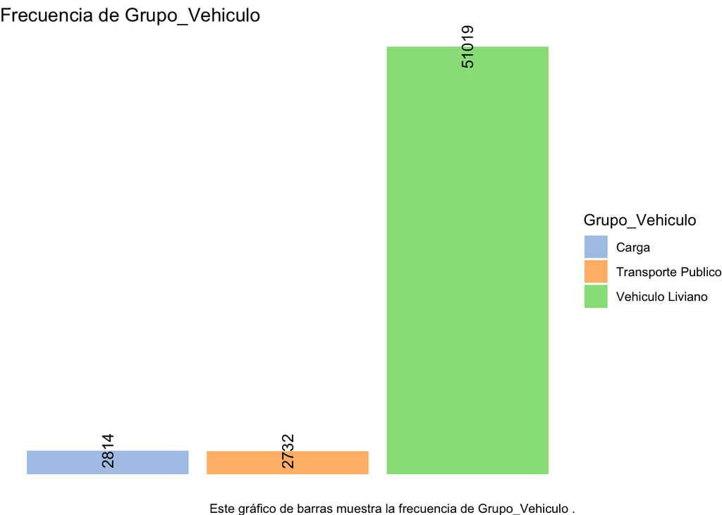

## Muestreo

```r
# Calcular la muestra aleatoria según Desviación Estándar
cant <- nrow(permiso_relevante)
sd <- sd(permiso_relevante$Valor_Pagado)
n <- tam.muestra(alfa = 0.05, epsilon = 1200, s = sd, N = cant)
set.seed(2)
cant <- sample(nrow(permiso_relevante), n)
permiso_muestra <- permiso_relevante[cant, ]

cat("La cantidad de registros de muestra es:", nrow(permiso_muestra))
```

```
## La cantidad de registros de muestra es: 12810
```

### Variable: Tipo de Pago

```r
var_x <- "Tipo_de_Pago"
var_tipo_grafico <- "barra"

grafico(
  data = permiso_muestra,
  var  = var_x,
  tipo_grafico = var_tipo_grafico
)
```

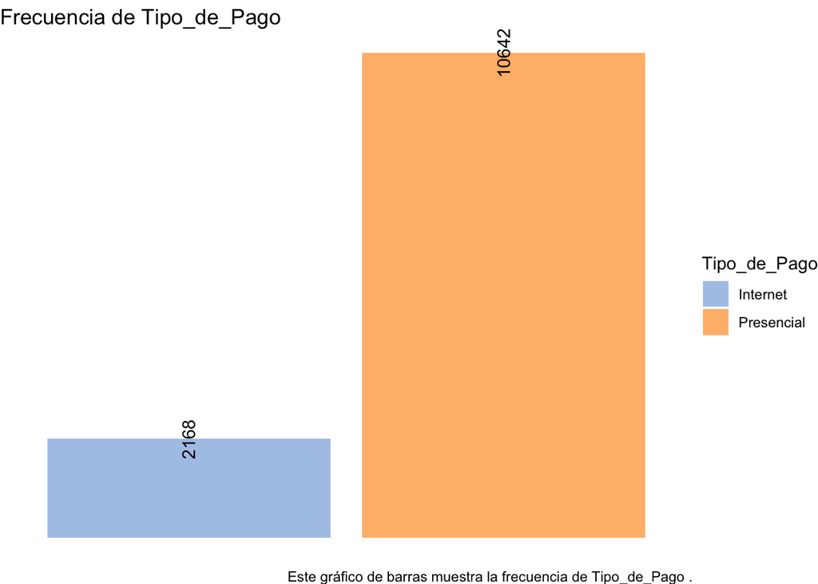

### Variable: Valor Pagado

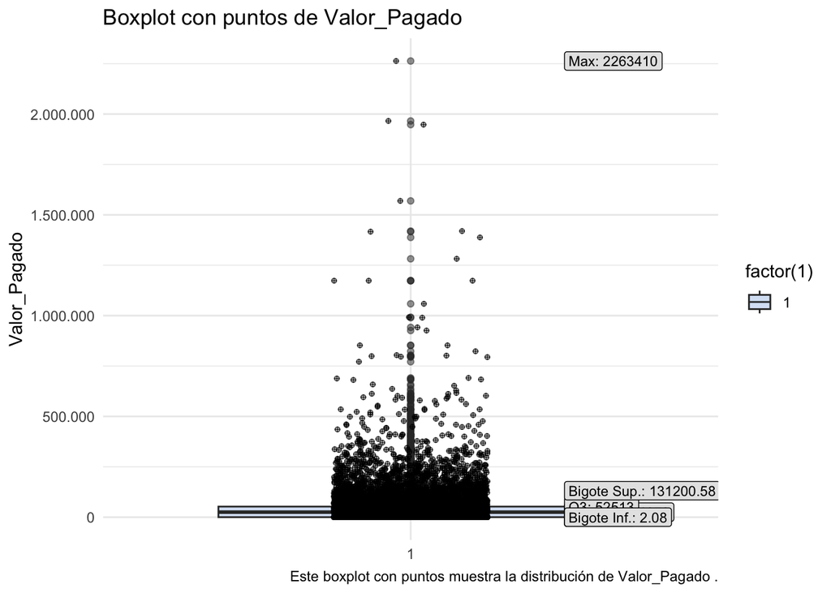

```r
vehiculo_liviano_dataset <- permiso_muestra %>% filter(`Grupo_Vehiculo` == "Vehiculo Liviano")
transporte_publico_dataset <- permiso_muestra %>% filter(`Grupo_Vehiculo` == "Transporte Publico")
carga_dataset <- permiso_muestra %>% filter(`Grupo_Vehiculo` == "Carga")



var_x <- "Valor_Pagado"
var_tipo_grafico <- "boxplot"

grafico(
  data = vehiculo_liviano_dataset,
  var  = var_x,
  tipo_grafico = var_tipo_grafico
)
```

```r
grafico(
  data = transporte_publico_dataset,
  var  = var_x,
  tipo_grafico = var_tipo_grafico
)
```

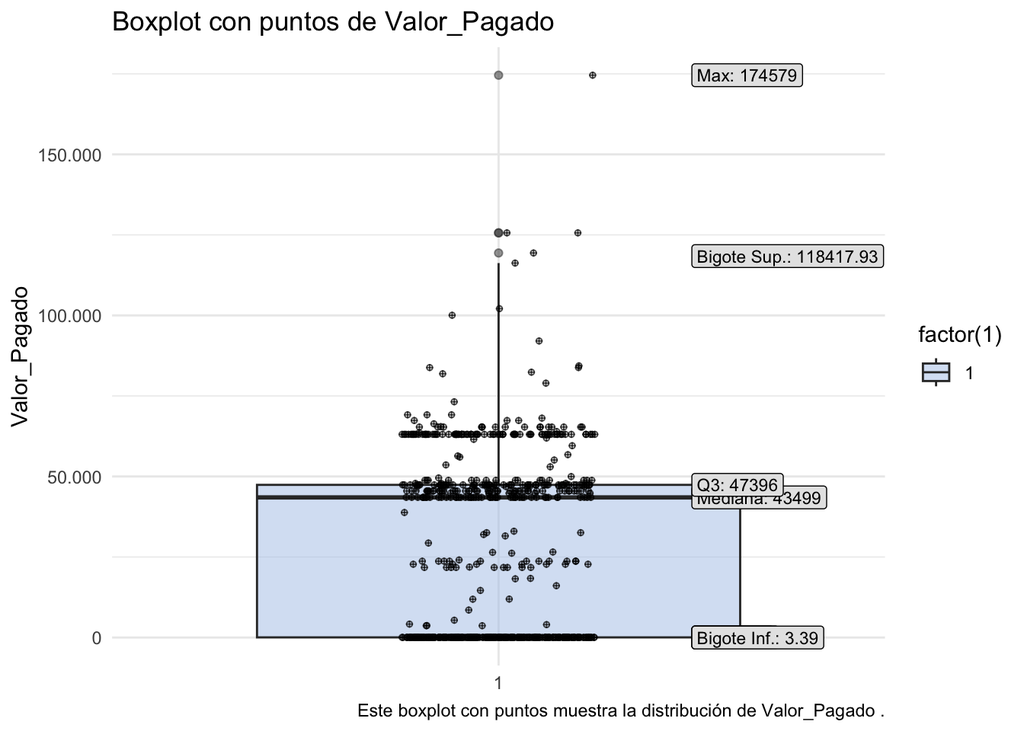

```r
grafico(
  data = carga_dataset,
  var  = var_x,
  tipo_grafico = var_tipo_grafico
)
```

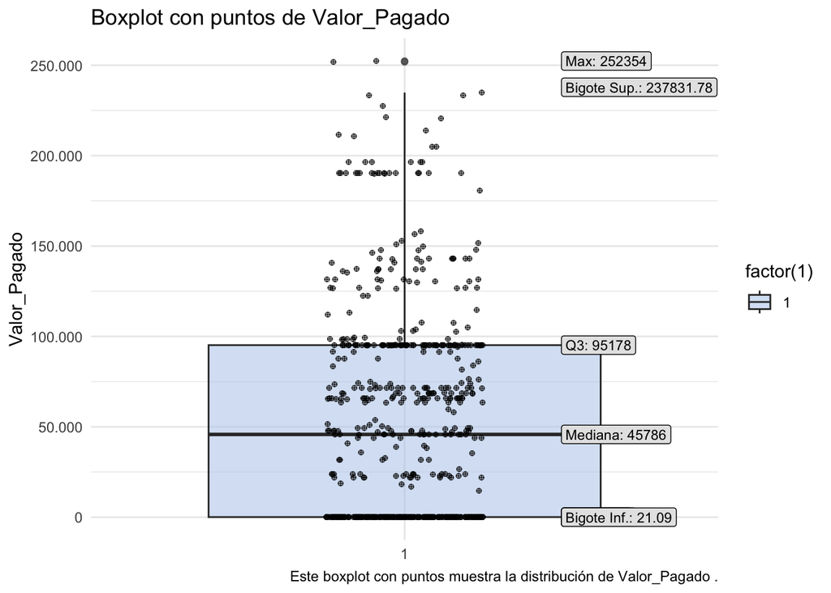

## Tratamiento de Outliers

```r
# Tratamiento de outliers
# Calcular el IQR y los límites para identificar valores atípicos
IQR_Valor_Pagado <- IQR(permiso_muestra$Valor_Pagado, na.rm = TRUE)
Q1 <- quantile(permiso_muestra$Valor_Pagado, 0.25, na.rm = TRUE)
Q3 <- quantile(permiso_muestra$Valor_Pagado, 0.75, na.rm = TRUE)
lower_bound <- Q1 - 1.5 * IQR_Valor_Pagado
upper_bound <- Q3 + 1.5 * IQR_Valor_Pagado

# Filtrar los valores atípicos
outliers <- permiso_muestra %>%
  filter(Valor_Pagado < lower_bound | Valor_Pagado > upper_bound)

# Eliminar los valores atípicos
permiso_sin_outliers <- permiso_muestra %>%
  filter(Valor_Pagado >= lower_bound & Valor_Pagado <= upper_bound)

cat("Número de registros originales:", nrow(permiso_muestra), "\n")
```

```
## Número de registros originales: 12810
```

```r
cat("Número de registros sin outliers:", nrow(permiso_sin_outliers), "\n")
```

```
## Número de registros sin outliers: 11850
```

```r
permiso_muestra<- permiso_sin_outliers
```

### Variable: Valor Pagado sin outliers

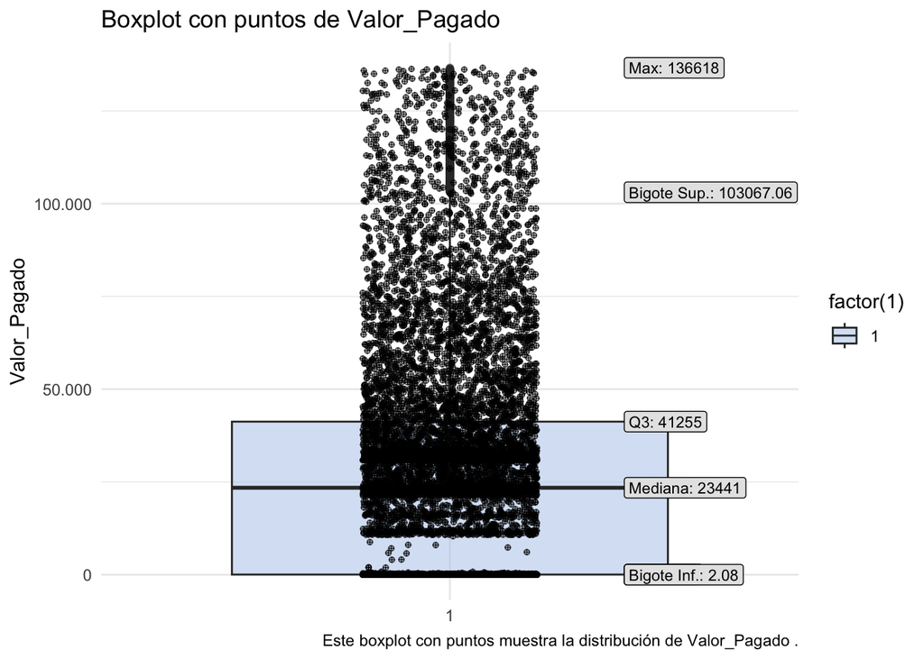

```r
vehiculo_liviano_dataset <- permiso_muestra %>% filter(`Grupo_Vehiculo` == "Vehiculo Liviano")
transporte_publico_dataset <- permiso_muestra %>% filter(`Grupo_Vehiculo` == "Transporte Publico")
carga_dataset <- permiso_muestra %>% filter(`Grupo_Vehiculo` == "Carga")



var_x <- "Valor_Pagado"
var_tipo_grafico <- "boxplot"

grafico(
  data = vehiculo_liviano_dataset,
  var  = var_x,
  tipo_grafico = var_tipo_grafico
)
```

```r
grafico(
  data = transporte_publico_dataset,
  var  = var_x,
  tipo_grafico = var_tipo_grafico
)
```

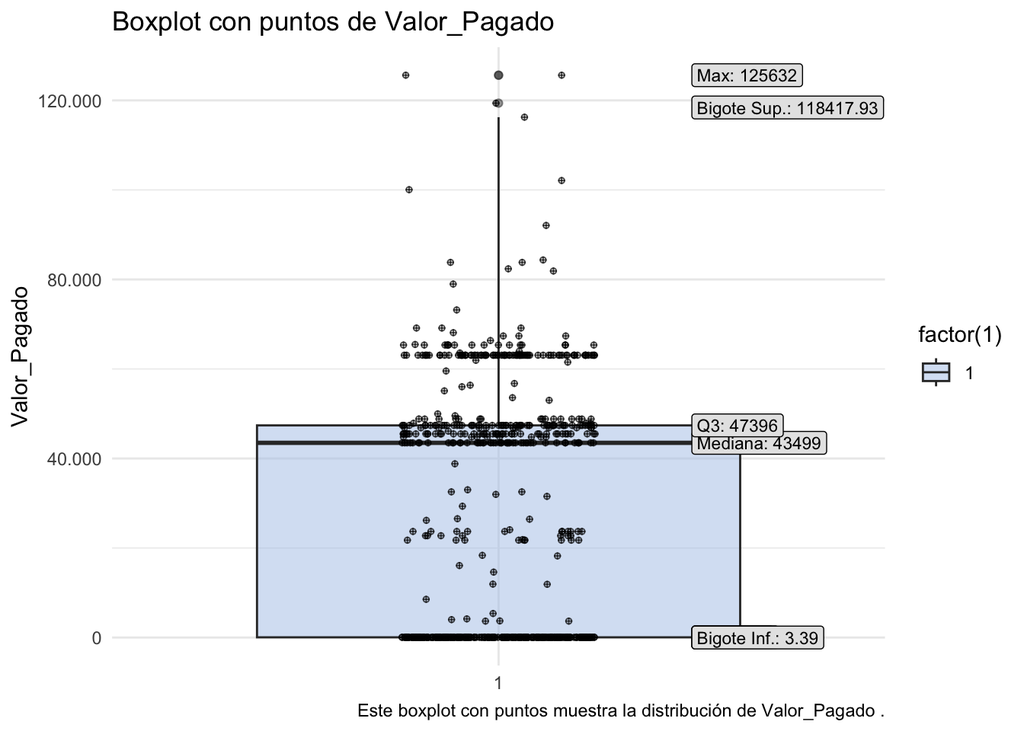

```r
grafico(
  data = carga_dataset,
  var  = var_x,
  tipo_grafico = var_tipo_grafico
)
```

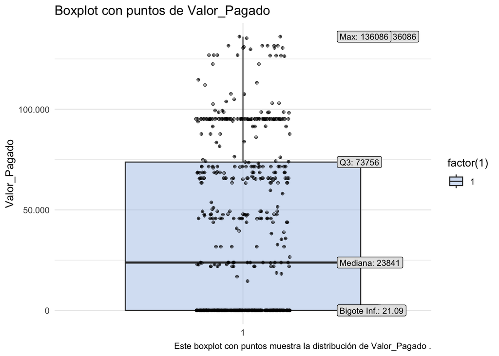

```r
var_x <- "Ano_Vehiculo"
var_y <- "Valor_Pagado"

grafico_dispersion(
  data = permiso_muestra,
  var_x = var_x,
  var_y = var_y
)
```

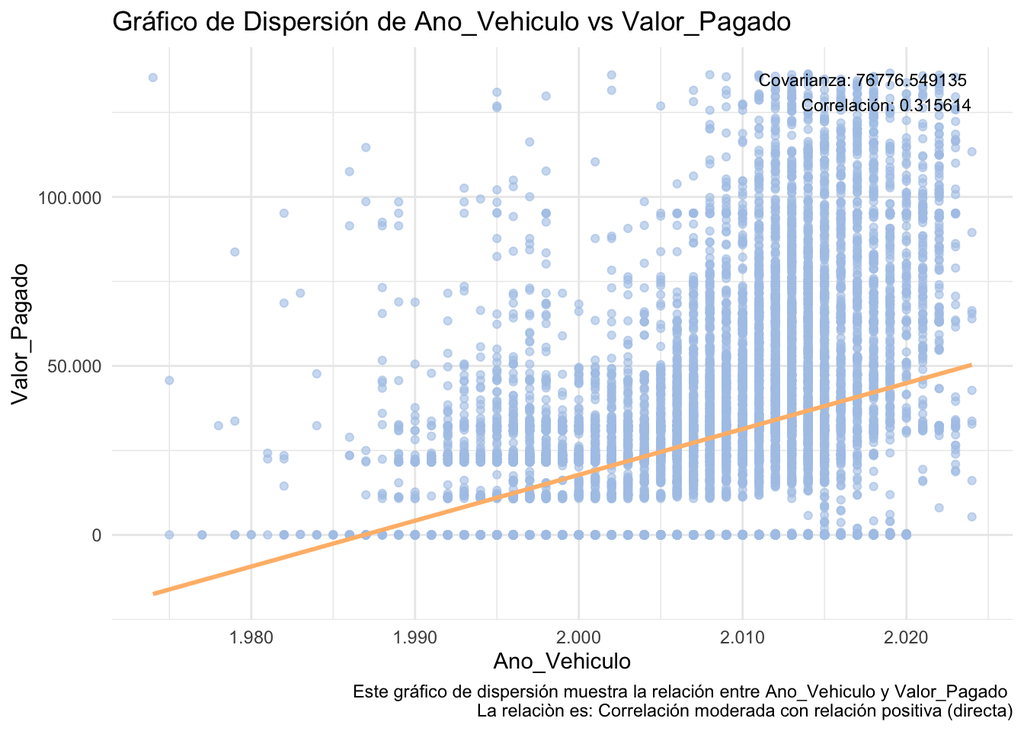

```r
# Medidas de tendencia central y dispersión
tendencia_central <- permiso_muestra %>%
  summarise(
    media_valor_pagado = mean(`Valor_Pagado`, na.rm = TRUE),
    mediana_valor_pagado = median(`Valor_Pagado`, na.rm = TRUE),
    desviacion_estandar_valor_pagado = sd(`Valor_Pagado`, na.rm = TRUE),
    varianza_valor_pagado = var(`Valor_Pagado`, na.rm = TRUE)
  )

print(tendencia_central)
```

```
##   media_valor_pagado mediana_valor_pagado desviacion_estandar_valor_pagado
## 1           29241.82                23510                         32329.62
##   varianza_valor_pagado
## 1            1045204079
```

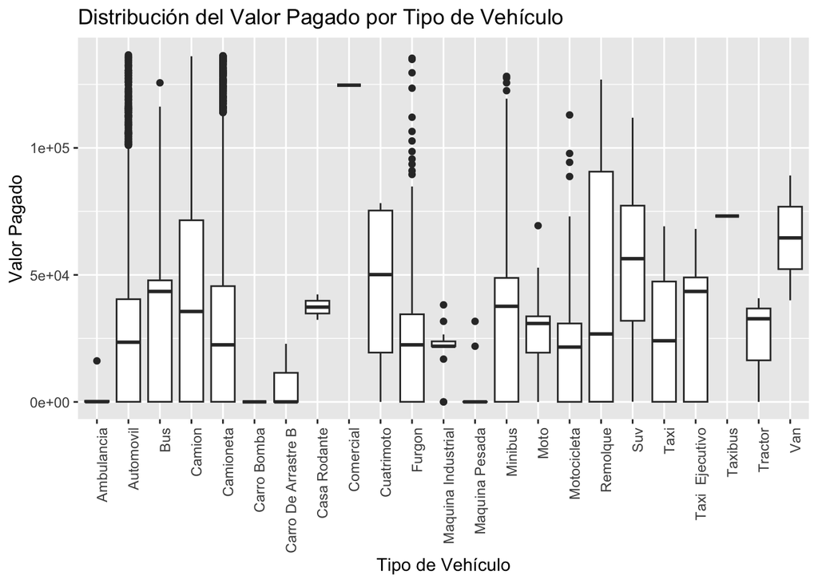

```r
# Boxplot de valor pagado por tipo de vehículo
ggplot(permiso_muestra, aes(x = `Tipo_Vehiculo`, y = `Valor_Pagado`)) +
  geom_boxplot() +
  labs(title = "Distribución del Valor Pagado por Tipo de Vehículo", x = "Tipo de Vehículo", y = "Valor Pagado") +
  theme(axis.text.x = element_text(angle = 90, hjust = 1))
```

## Distribucion de Pagos en Grupos de Vehiculos por Meses Relativos

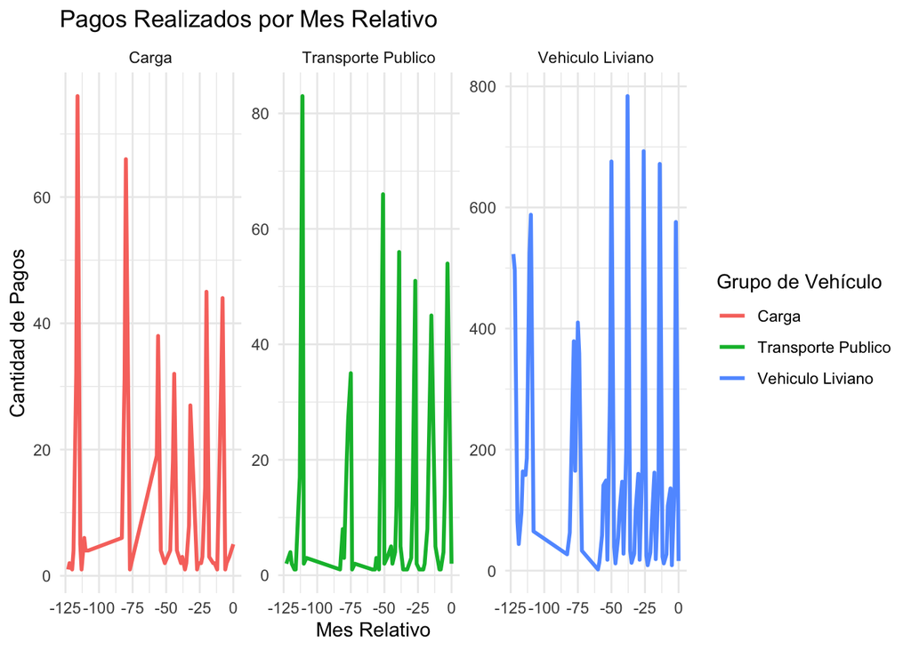

```r
# Filtrar y transformar los datos

# Calcular el mes relativo
permiso_muestra <- permiso_muestra %>%
  arrange(Fecha_Pago) %>%
  group_by(Grupo_Vehiculo) %>%
  mutate(
    Fecha_Relativa = as.yearmon(Fecha_Pago),
    Mes_Relativo = as.integer((min(Fecha_Relativa) - Fecha_Relativa) * 12)
  ) %>%
  ungroup()

# Resumir los datos por mes relativo y grupo de vehículo
pagos_por_mes_relativo <- permiso_muestra %>%
  group_by(Grupo_Vehiculo, Mes_Relativo) %>%
  summarise(Cantidad_Pagos = n(), .groups = 'drop')

# Crear el gráfico
ggplot(pagos_por_mes_relativo, aes(x = Mes_Relativo, y = Cantidad_Pagos, color = Grupo_Vehiculo)) +
  geom_line(size = 1) +
  facet_wrap(~ Grupo_Vehiculo, scales = "free_y") +
  labs(title = "Pagos Realizados por Mes Relativo",
       x = "Mes Relativo",
       y = "Cantidad de Pagos",
       color = "Grupo de Vehículo") +
  theme_minimal()
```

## Valores Nulos y reemplazar por la Mediana

En caso que se encuentren valores, se reemplazan por el valor de la mediana de cada variable.

```r
#Imputar valores nulos por la mediana
permiso_muestra <- permiso_muestra %>%
  mutate(across(everything(), reemplazar_por_mediana))
```

## Descripcion de Variables normalizadas

```r
# Configurar el entorno de summarytools para HTML
st_options(style = "rmarkdown", plain.ascii = FALSE)

# Obtener un resumen de los datos utilizando summarytools y renderizar en HTML
dfSummary(permiso_muestra) %>%
  print(method = 'render')
```

Data Frame Summary

permiso_muestra

**Dimensions**: 11850 x 16  
**Duplicates**: 178

| **No** | **Variable** | **Stats / Values** | **Freqs (% of Valid)** | **Graph** | **Valid** | **Missing** |
| --- | --- | --- | --- | --- | --- | --- |
| 1 | Grupo_Vehiculo [factor] | 1. Carga 2. Transporte Publico 3. Vehiculo Liviano | 565 ( 4.8% ) 636 ( 5.4% ) 10649 ( 89.9% ) |  | 11850 (100.0%) | 0 (0.0%) |
| 2 | Ano_Vehiculo [integer] | Mean (sd) : 2008.4 (7.5) min ≤ med ≤ max: 1974 ≤ 2010 ≤ 2024 IQR (CV) : 10 (0) | 50 distinct values |  | 11850 (100.0%) | 0 (0.0%) |
| 3 | Tipo_de_Pago [factor] | 1. Internet 2. Presencial | 2034 ( 17.2% ) 9816 ( 82.8% ) |  | 11850 (100.0%) | 0 (0.0%) |
| 4 | Fecha_Pago [Date] | min : 2014-01-03 med : 2018-03-29 max : 2024-05-11 range : 10y 4m 8d | 1387 distinct values |  | 11850 (100.0%) | 0 (0.0%) |
| 5 | Ano_Pago [numeric] | Mean (sd) : 2018.7 (3.3) min ≤ med ≤ max: 2014 ≤ 2018 ≤ 2024 IQR (CV) : 7 (0) | 2014 : 1184 ( 10.0% ) 2015 : 1281 ( 10.8% ) 2016 : 1319 ( 11.1% ) 2017 : 1502 ( 12.7% ) 2018 : 1560 ( 13.2% ) 2019 : 2 ( 0.0% ) 2020 : 1810 ( 15.3% ) 2023 : 2080 ( 17.6% ) 2024 : 1112 ( 9.4% ) |  | 11850 (100.0%) | 0 (0.0%) |
| 6 | Mes_Pago_texto [ordered, factor] | 1. Jan 2. Feb 3. Mar 4. Apr 5. May 6. Jun 7. Jul 8. Aug 9. Sep 10. Oct [ 2 others ] | 122 ( 1.0% ) 231 ( 1.9% ) 4871 ( 41.1% ) 1818 ( 15.3% ) 1000 ( 8.4% ) 570 ( 4.8% ) 327 ( 2.8% ) 1033 ( 8.7% ) 1195 ( 10.1% ) 369 ( 3.1% ) 314 ( 2.6% ) |  | 11850 (100.0%) | 0 (0.0%) |
| 7 | Mes_Pago [numeric] | Mean (sd) : 5 (2.6) min ≤ med ≤ max: 1 ≤ 4 ≤ 12 IQR (CV) : 4 (0.5) | 12 distinct values |  | 11850 (100.0%) | 0 (0.0%) |
| 8 | Valor_Neto [numeric] | Mean (sd) : 28580.1 (31614) min ≤ med ≤ max: 2.1 ≤ 23505 ≤ 136618 IQR (CV) : 43414 (1.1) | 6539 distinct values |  | 11850 (100.0%) | 0 (0.0%) |
| 9 | Valor_IPC [factor] | 1. · 2. 0 3. 0,00E+00 4. 1 5. 1.000 6. 1.001 7. 1.002 8. 1.003 9. 1.006 10. 1.007 [ 2774 others ] | 0 ( 0.0% ) 9273 ( 78.3% ) 2 ( 0.0% ) 0 ( 0.0% ) 0 ( 0.0% ) 0 ( 0.0% ) 0 ( 0.0% ) 3 ( 0.0% ) 0 ( 0.0% ) 0 ( 0.0% ) 2572 ( 21.7% ) |  | 11850 (100.0%) | 0 (0.0%) |
| 10 | Valor_Multa [numeric] | Mean (sd) : 539.1 (2256.6) min ≤ med ≤ max: 0 ≤ 0 ≤ 46627 IQR (CV) : 2.3 (4.2) | 1727 distinct values |  | 11850 (100.0%) | 0 (0.0%) |
| 11 | Valor_Pagado [numeric] | Mean (sd) : 29241.8 (32329.6) min ≤ med ≤ max: 2.1 ≤ 23510 ≤ 136618 IQR (CV) : 44725.6 (1.1) | 6557 distinct values |  | 11850 (100.0%) | 0 (0.0%) |
| 12 | Forma_Pago [factor] | 1. 1ra. Cuota 2. 2da. Cuota 3. Total | 2449 ( 20.7% ) 2039 ( 17.2% ) 7362 ( 62.1% ) |  | 11850 (100.0%) | 0 (0.0%) |
| 13 | Tipo_Vehiculo [factor] | 1. Ambulancia 2. Automovil 3. Bicimoto 4. Bus 5. Camion 6. Camioneta 7. Cargador Frontal 8. Carro Bomba 9. Carro De Arrastre B 10. Casa Rodante [ 18 others ] | 7 ( 0.1% ) 6277 ( 53.0% ) 0 ( 0.0% ) 148 ( 1.2% ) 394 ( 3.3% ) 3637 ( 30.7% ) 0 ( 0.0% ) 1 ( 0.0% ) 3 ( 0.0% ) 2 ( 0.0% ) 1381 ( 11.7% ) |  | 11850 (100.0%) | 0 (0.0%) |
| 14 | Marca [factor] | 1. 208 2. Aerovan 3. Agrale 4. Ale 5. Alfa Romero 6. American Motors 7. Asia Motors 8. Audi 9. Austin 10. Autorrad [ 226 others ] | 0 ( 0.0% ) 1 ( 0.0% ) 3 ( 0.0% ) 1 ( 0.0% ) 0 ( 0.0% ) 3 ( 0.0% ) 2 ( 0.0% ) 2 ( 0.0% ) 0 ( 0.0% ) 2 ( 0.0% ) 11836 ( 99.9% ) |  | 11850 (100.0%) | 0 (0.0%) |
| 15 | Fecha_Relativa [yearmon] |  | 90 distinct values |  | 11850 (100.0%) | 0 (0.0%) |
| 16 | Mes_Relativo [integer] | Mean (sd) : -59.9 (40) min ≤ med ≤ max: -123 ≤ -50 ≤ 0 IQR (CV) : 84 (-0.7) | 60 distinct values |  | 11850 (100.0%) | 0 (0.0%) |

Generated by summarytools 1.0.1 ([R](https://www.r-project.org/) version 4.4.0)  
2024-06-22

# 4. Modelado de Datos

## Técnicas y Algoritmos

### 2. Entrenamiento y Evaluación

### Seleccionar los datos

```r
# Configurar semilla para reproducibilidad
set.seed(123)

# Filtrar los datos hasta el año 2018
filtered_permiso_muestra <- permiso_muestra %>%
  filter(Ano_Pago <= 2018)

# Definir el tamaño de la muestra por cada categoría de Grupo_Vehiculo
tamano_muestra <- min(filtered_permiso_muestra %>% count(Grupo_Vehiculo) %>% pull(n))

# Muestreo estratificado para asegurar la misma cantidad de datos por categoría
filtered_permiso_muestra <- filtered_permiso_muestra %>%
  group_by(Grupo_Vehiculo) %>%
  sample_n(tamano_muestra) %>%
  ungroup()


var_x <- "Grupo_Vehiculo"
var_tipo_grafico <- "barra"

grafico(
  data = filtered_permiso_muestra,
  var  = var_x,
  tipo_grafico = var_tipo_grafico
)
```

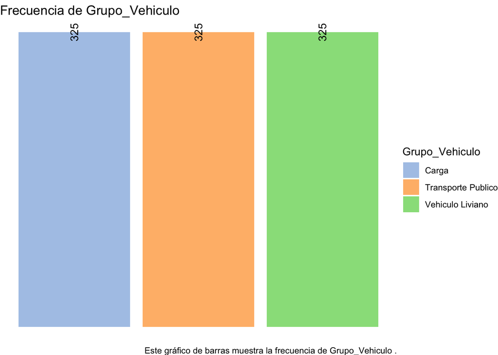

### Seleccionar Datos

```r
# Calcular el mes relativo
filtered_permiso_muestra <- filtered_permiso_muestra %>%
  arrange(Fecha_Pago) %>%
  group_by(Grupo_Vehiculo) %>%
  mutate(
    Fecha_Relativa = as.yearmon(Fecha_Pago),
    Mes_Relativo = as.integer((min(Fecha_Relativa) - Fecha_Relativa) * 12)
  ) %>%
  ungroup()

# Crear la variable de cantidad de permisos por grupo de vehículo
cantidad_permisos <- filtered_permiso_muestra %>%
  group_by(Grupo_Vehiculo, Mes_Relativo) %>%
  summarise(Cantidad_Permisos = n(), .groups = 'drop')

# Preparar datos con todas las variables
datos_completos <- filtered_permiso_muestra %>%
  left_join(cantidad_permisos, by = c("Grupo_Vehiculo", "Mes_Relativo"))

# Convertir variables categóricas a factores
datos_completos <- datos_completos %>%
  mutate_if(is.character, as.factor)

# Dividir los datos en conjuntos de entrenamiento (80%) y prueba (20%)
set.seed(1234)
trainIndex <- createDataPartition(datos_completos$Cantidad_Permisos, p = .8,
                                  list = FALSE,
                                  times = 1)
permisoTrain <- datos_completos[trainIndex,]
permisoTest  <- datos_completos[-trainIndex,]

# Asegurar que los niveles de las variables categóricas sean consistentes entre entrenamiento y prueba
permisoTest <- permisoTest %>%
  mutate(across(where(is.factor), ~ factor(.x, levels = levels(permisoTrain[[cur_column()]]))))

# Convertir variables categóricas a indicadores binarios (dummies)
permisoTrain_matrix <- model.matrix(~ . - 1, data = permisoTrain %>% select(-Cantidad_Permisos))
permisoTest_matrix <- model.matrix(~ . - 1, data = permisoTest %>% select(-Cantidad_Permisos))

# Crear DMatrix para XGBoost
dtrain_cantidad <- xgb.DMatrix(data = permisoTrain_matrix, label = permisoTrain$Cantidad_Permisos)
dtest_cantidad <- xgb.DMatrix(data = permisoTest_matrix, label = permisoTest$Cantidad_Permisos)

# Definir parámetros para el modelo XGBoost
params <- list(booster = "gbtree", objective = "reg:squarederror", eta = 0.3, max_depth = 6)

# Entrenar el modelo XGBoost
modelo_xgb_cantidad <- xgb.train(params, dtrain_cantidad, nrounds = 100)

# Evaluar el modelo
pred_xgb_cantidad <- predict(modelo_xgb_cantidad, dtest_cantidad)
rmse_xgb_cantidad <- RMSE(pred_xgb_cantidad, permisoTest$Cantidad_Permisos)
rsq_xgb_cantidad <- R2(pred_xgb_cantidad, permisoTest$Cantidad_Permisos)

# Mostrar resultados del modelo
resultados_cantidad <- tibble(
  Modelo = "XGBoost",
  RMSE = rmse_xgb_cantidad,
  R2 = rsq_xgb_cantidad
)

print(resultados_cantidad)
```

```
## # A tibble: 1 × 3
##   Modelo   RMSE    R2
##   <chr>   <dbl> <dbl>
## 1 XGBoost  3.90 0.952
```